# Finding Bad Data with R

Minghao Du

This instruction document is generated with R Markdown. This exercise will introduce you to the basic of R Markdown and a very powerful R package for data management and exploratory analysis, `tidyverse`.

In this exercise, you’ll be working with a partial data set of orders for an imaginary company, Vandelay Industries. The data set contains the total amount and zip code information for 45,808 orders placed between January, 2009 and January, 2014.

# R & R Markdown Basic

Again, this is an [R Markdown](http://rmarkdown.rstudio.com) Notebook. When you execute code within the notebook, the results appear beneath the code.

```r
print("Data Science Rocks!")
```

```
[1] "Data Science Rocks!"
```

Okay. Let’s get started.

## Clear the workspace

It is (almost always) good to start with a clean R workspace. It ensures that your results will be reproducible whenever you run the codes.

```r
rm(list = ls())
```

## Libraries and Packages

There are various libraries or packages for R for special topics or specialized methods. In order to download a new package, go to *Tools* and select *Install package(s)*. Select your region and then the package you wish to install. Alternatively, you can manually install a package using the comment `install.packages()`. Once a package has been installed (for example, the package *tidyverse*), it can be added to an R session by the command, `library()`

```r
if(!require(backports))install.packages("backports")
```

[output not shown]

```r
if(!require(tidyverse))install.packages("tidyverse")
```

```
  method         from
  print.tbl_lazy
  print.tbl_sql
```

```r
if(!require(readxl))install.packages("readxl")

library(tidyverse)
library(readxl)
```

When a package has been downloaded once, it is not necessary to download it again. However, unless the workspace is saved and reloaded, the packages must be added to the session every time R is restarted.

## Functions and commands

Functions in R can have quite a number of parameters, which are set to a default value. To change it, enter the parameter name, followed by “=“ and the new value of the parameter.

If detailed information about R function or command is needed, you can use `help()` function. To check what `library()` function is for:

```r
help(library)
```

If you do not know the name of the function for your analysis, simply Google your question!

# Import Data from Excel

You can import data in various formats into R. For this exercise, we will import data from Microsoft Excel. Download *Vandelay Orders by Zipcode.xlsx* from the course Blackboard site.

Remember where you saved it! The best way is to save the data file in the same folder where this markdown file is saved.

Before importing the data, open the file in Microsoft Excel. Take a look through the order data (the “Vandelay Order by Zip” tab), and the data dictionary (the “Data Dictionary” tab).

Let’s import the data into R using R studio’s data import wizard. Click Environment on the upper-right side of R studio, click “Import Dataset”

Then, a new window will pop up. Select the file that you’ve saved.

Once you select the file, it will give you the preview of the dataset in the default sheet in the Excel file. You can change the import options as you want. We will make three changes.

- Change the name to *order*.
- Change the type of order_short_date to *date*.
- Change the type of zip_code to *character*.

You will see that the command (which starts with order<-read_excel…) for importing the dataset in the Console window. Copy the command to the script file for your convenience. Here is the code that works on *my computer*. It works because I saved the data file and this markdown file in the same folder. If you saved the data file in a different folder, this code would not work on your computer. Try again, after moving the data file into the correct place.

```r
order <- read_excel("Vandelay-Orders-by-Zipcode.xlsx",
                    col_types = c("numeric", "numeric", "date","numeric", "text"))

head(order)
```

| customer_id | order_id | order_short_date | order_total | zip_code |
| --- | --- | --- | --- | --- |
| 1 | 1 | 2009-01-01 | 404.72 | 32435 |
| 1 | 33658 | 2013-02-15 | 71.10 | 32435 |
| 2 | 2 | 2009-01-01 | 288.62 | 1099 |
| 2 | 1653 | 2010-01-03 | 182.86 | 1099 |
| 2 | 4193 | 2010-09-12 | 108.43 | 1099 |
| 3 | 3 | 2009-01-01 | 27.15 | 66063 |

```r
nrow(order)
```

```
[1] 45808
```

The first thing we want to verify is that every zip code in the data set is a valid postal code of the US Postal Service. To do this, we need a list of the correct zip codes. You can find this from various online sources.

I’ve already imported a list of zip codes into your workbook. You’ll find them under the ZipCodeStateLookup tab. Take a quick look at that tab and check out the data on that spreadsheet.

You can see that it would take a very long time to manually search for each order’s zip code in the lookup table. So we need a quicker way to do that. We will use the merge function in R.

Import the zip code data as `zipcode`. Select the same Excel file (Vandelay Orders by Zipcode.xlsx) and choose “ZipCodeStateLookup”.

Let’s change the name to `zipcode` and the type of zip column to character.

```r
zipcode <- read_excel("Vandelay-Orders-by-Zipcode.xlsx", sheet = "ZipCodeStateLookup",
                      col_types = c("text","text"))

head(order)
```

| customer_id | order_id | order_short_date | order_total | zip_code |
| --- | --- | --- | --- | --- |
| 1 | 1 | 2009-01-01 | 404.72 | 32435 |
| 1 | 33658 | 2013-02-15 | 71.10 | 32435 |
| 2 | 2 | 2009-01-01 | 288.62 | 1099 |
| 2 | 1653 | 2010-01-03 | 182.86 | 1099 |
| 2 | 4193 | 2010-09-12 | 108.43 | 1099 |
| 3 | 3 | 2009-01-01 | 27.15 | 66063 |

```r
head(zipcode)
```

| zip | state |
| --- | --- |
| 501 | NY |
| 544 | NY |
| 601 | PR |
| 602 | PR |
| 603 | PR |
| 604 | PR |

# Tidying data & data exploration

I’d like to introduce `tidyverse` package, which is a very handy tool to save you from sleepless nights. Let’s save the datasets in a tidy format using `as.tibble()`.

```r
order<-as.tibble(order)
```

```
`as.tibble()` is deprecated as of tibble 2.0.0.
Please use `as_tibble()` instead.
The signature and semantics have changed, see `?as_tibble`.
```

```r
zipcode<-as.tibble(zipcode)

order
```

| customer_id | order_id | order_short_date | order_total | zip_code |
| --- | --- | --- | --- | --- |
| 1 | 1 | 2009-01-01 | 404.72 | 32435 |
| 1 | 33658 | 2013-02-15 | 71.10 | 32435 |
| 2 | 2 | 2009-01-01 | 288.62 | 1099 |
| 2 | 1653 | 2010-01-03 | 182.86 | 1099 |
| 2 | 4193 | 2010-09-12 | 108.43 | 1099 |
| 3 | 3 | 2009-01-01 | 27.15 | 66063 |
| 3 | 240 | 2009-04-08 | 348.60 | 66063 |
| 3 | 13184 | 2011-11-20 | 107.41 | 66063 |
| 3 | 39776 | 2013-05-16 | 39.54 | 66063 |
| 4 | 4 | 2009-01-02 | 169.68 | 21252 |

[output cut: 990 more lines]

```r
zipcode
```

| zip | state |
| --- | --- |
| 501 | NY |
| 544 | NY |
| 601 | PR |
| 602 | PR |
| 603 | PR |
| 604 | PR |
| 605 | PR |
| 606 | PR |
| 610 | PR |
| 611 | PR |

[output cut: 990 more lines]

Base R functions are still useful.

```r
print(order) # print the dataset
```

| customer_id | order_id | order_short_date | order_total | zip_code |
| --- | --- | --- | --- | --- |
| 1 | 1 | 2009-01-01 | 404.72 | 32435 |
| 1 | 33658 | 2013-02-15 | 71.10 | 32435 |
| 2 | 2 | 2009-01-01 | 288.62 | 1099 |
| 2 | 1653 | 2010-01-03 | 182.86 | 1099 |
| 2 | 4193 | 2010-09-12 | 108.43 | 1099 |
| 3 | 3 | 2009-01-01 | 27.15 | 66063 |
| 3 | 240 | 2009-04-08 | 348.60 | 66063 |
| 3 | 13184 | 2011-11-20 | 107.41 | 66063 |
| 3 | 39776 | 2013-05-16 | 39.54 | 66063 |
| 4 | 4 | 2009-01-02 | 169.68 | 21252 |

[output cut: 990 more lines]

```r
head (order) # show first six rows
```

| customer_id | order_id | order_short_date | order_total | zip_code |
| --- | --- | --- | --- | --- |
| 1 | 1 | 2009-01-01 | 404.72 | 32435 |
| 1 | 33658 | 2013-02-15 | 71.10 | 32435 |
| 2 | 2 | 2009-01-01 | 288.62 | 1099 |
| 2 | 1653 | 2010-01-03 | 182.86 | 1099 |
| 2 | 4193 | 2010-09-12 | 108.43 | 1099 |
| 3 | 3 | 2009-01-01 | 27.15 | 66063 |

```r
head (order,10) # specify the number of rows to print
```

| customer_id | order_id | order_short_date | order_total | zip_code |
| --- | --- | --- | --- | --- |
| 1 | 1 | 2009-01-01 | 404.72 | 32435 |
| 1 | 33658 | 2013-02-15 | 71.10 | 32435 |
| 2 | 2 | 2009-01-01 | 288.62 | 1099 |
| 2 | 1653 | 2010-01-03 | 182.86 | 1099 |
| 2 | 4193 | 2010-09-12 | 108.43 | 1099 |
| 3 | 3 | 2009-01-01 | 27.15 | 66063 |
| 3 | 240 | 2009-04-08 | 348.60 | 66063 |
| 3 | 13184 | 2011-11-20 | 107.41 | 66063 |
| 3 | 39776 | 2013-05-16 | 39.54 | 66063 |
| 4 | 4 | 2009-01-02 | 169.68 | 21252 |

```r
tail (order) # show the last six rows
```

| customer_id | order_id | order_short_date | order_total | zip_code |
| --- | --- | --- | --- | --- |
| 10710 | 63173 | 2014-01-27 | 59.54 | 14140 |
| 10711 | 24852 | 2012-09-15 | 113.26 | 44618 |
| 10711 | 46950 | 2013-08-17 | 170.21 | 44618 |
| 10712 | 24853 | 2012-09-15 | 155.49 | 37184 |
| 10713 | 24854 | 2012-09-15 | 309.56 | 3447 |
| 10714 | 24855 | 2012-09-15 | 55.01 | 34108 |

```r
tail (order,10) # specify the number of rows to print
```

| customer_id | order_id | order_short_date | order_total | zip_code |
| --- | --- | --- | --- | --- |
| 10710 | 47681 | 2013-08-24 | 116.01 | 14140 |
| 10710 | 49874 | 2013-09-17 | 118.08 | 14140 |
| 10710 | 56752 | 2013-12-01 | 93.62 | 14140 |
| 10710 | 61188 | 2014-01-11 | 37.83 | 14140 |
| 10710 | 63173 | 2014-01-27 | 59.54 | 14140 |
| 10711 | 24852 | 2012-09-15 | 113.26 | 44618 |
| 10711 | 46950 | 2013-08-17 | 170.21 | 44618 |
| 10712 | 24853 | 2012-09-15 | 155.49 | 37184 |
| 10713 | 24854 | 2012-09-15 | 309.56 | 3447 |
| 10714 | 24855 | 2012-09-15 | 55.01 | 34108 |

```r
summary(order) # basic summary statistics
```

```
  customer_id       order_id     order_short_date               order_total
 Min.   :    1   Min.   :    1   Min.   :2009-01-01 00:00:00   Min.   :    0.00
 1st Qu.:  815   1st Qu.:11453   1st Qu.:2011-09-18 00:00:00   1st Qu.:   31.19
 Median : 2487   Median :22905   Median :2012-08-06 00:00:00   Median :   71.46
 Mean   : 3424   Mean   :26511   Mean   :2012-06-13 02:31:27   Mean   :  157.87
 3rd Qu.: 5528   3rd Qu.:41100   3rd Qu.:2013-06-04 00:00:00   3rd Qu.:  159.45
 Max.   :10714   Max.   :63288   Max.   :2014-01-28 00:00:00   Max.   :58409.20
   zip_code
 Length:45808
 Class :character
 Mode  :character
```

```r
names(order)   # check variable names
```

```
[1] "customer_id"      "order_id"         "order_short_date" "order_total"
[5] "zip_code"
```

```r
nrow(order)    # number of rows
```

```
[1] 45808
```

```r
ncol(order)    # number of columns
```

```
[1] 5
```

```r
dim(order)    # dimension of data
```

```
[1] 45808     5
```

`glimpse()` provides a preview of data with helpful details. It is very handy especially when you have to deal with a dataset with many variables.

```r
glimpse(order)
```

```
Rows: 45,808
Columns: 5
$ customer_id      <dbl> 1, 1, 2, 2, 2, 3, 3, 3, 3, 4, 4, 4, 5, 5, 5, 5, 5, 5, 5, 5, 5, ~
$ order_id         <dbl> 1, 33658, 2, 1653, 4193, 3, 240, 13184, 39776, 4, 36967, 55054,~
$ order_short_date <dttm> 2009-01-01, 2013-02-15, 2009-01-01, 2010-01-03, 2010-09-12, 20~
$ order_total      <dbl> 404.72, 71.10, 288.62, 182.86, 108.43, 27.15, 348.60, 107.41, 3~
$ zip_code         <chr> "32435", "32435", "1099", "1099", "1099", "66063", "66063", "66~
```

```r
glimpse(zipcode)
```

```
Rows: 42,523
Columns: 2
$ zip   <chr> "501", "544", "601", "602", "603", "604", "605", "606", "610", "611", "612~
$ state <chr> "NY", "NY", "PR", "PR", "PR", "PR", "PR", "PR", "PR", "PR", "PR", "PR", "P~
```

To access a specific attribute of an object, write the name of the object, followed by the symbol $ and then by the name of the variable:

```r
head(order$zip_code)
```

```
[1] "32435" "32435" "1099"  "1099"  "1099"  "66063"
```

A column of the data table can be accessed by using its index in square brackets:

```r
head(order[2])
```

| order_id |
| --- |
| 1 |
| 33658 |
| 2 |
| 1653 |
| 4193 |
| 3 |

A row of the data table can be selected as follows:

```r
order[23,]
```

| customer_id | order_id | order_short_date | order_total | zip_code |
| --- | --- | --- | --- | --- |
| 5 | 40258 | 2013-05-22 | 20.32 | 18003 |

# Merge datasets

Let’s merge the two datasets: `order` and `zipcode`.

```r
head(order)
```

| customer_id | order_id | order_short_date | order_total | zip_code |
| --- | --- | --- | --- | --- |
| 1 | 1 | 2009-01-01 | 404.72 | 32435 |
| 1 | 33658 | 2013-02-15 | 71.10 | 32435 |
| 2 | 2 | 2009-01-01 | 288.62 | 1099 |
| 2 | 1653 | 2010-01-03 | 182.86 | 1099 |
| 2 | 4193 | 2010-09-12 | 108.43 | 1099 |
| 3 | 3 | 2009-01-01 | 27.15 | 66063 |

```r
head(zipcode)
```

| zip | state |
| --- | --- |
| 501 | NY |
| 544 | NY |
| 601 | PR |
| 602 | PR |
| 603 | PR |
| 604 | PR |

These two lines do basically the same thing.

```r
# merge the order and zip code tables
order_zipcode<-merge(order,zipcode,by.x="zip_code",by.y="zip",all.x=TRUE)
order_zipcode<-left_join(order,zipcode,by=c("zip_code"="zip"))
```

Using the pipe operator, the second line can be re-written as:

```r
order_zipcode<-order%>%
  left_join(zipcode,by=c("zip_code"="zip"))
```

Check the first few rows using head or View:

```r
head(order_zipcode)
```

| customer_id | order_id | order_short_date | order_total | zip_code | state |
| --- | --- | --- | --- | --- | --- |
| 1 | 1 | 2009-01-01 | 404.72 | 32435 | FL |
| 1 | 33658 | 2013-02-15 | 71.10 | 32435 | FL |
| 2 | 2 | 2009-01-01 | 288.62 | 1099 | NA |
| 2 | 1653 | 2010-01-03 | 182.86 | 1099 | NA |
| 2 | 4193 | 2010-09-12 | 108.43 | 1099 | NA |
| 3 | 3 | 2009-01-01 | 27.15 | 66063 | KS |

```r
#View(order_zipcode)
```

# Finding missing values

You’ll see some of the cells have a “NA” value. This means that those zip codes weren’t found in the official table (there’s no row where that value exists) and therefore aren’t valid.

```r
order_zipcode
```

| customer_id | order_id | order_short_date | order_total | zip_code | state |
| --- | --- | --- | --- | --- | --- |
| 1 | 1 | 2009-01-01 | 404.72 | 32435 | FL |
| 1 | 33658 | 2013-02-15 | 71.10 | 32435 | FL |
| 2 | 2 | 2009-01-01 | 288.62 | 1099 | NA |
| 2 | 1653 | 2010-01-03 | 182.86 | 1099 | NA |
| 2 | 4193 | 2010-09-12 | 108.43 | 1099 | NA |
| 3 | 3 | 2009-01-01 | 27.15 | 66063 | KS |
| 3 | 240 | 2009-04-08 | 348.60 | 66063 | KS |
| 3 | 13184 | 2011-11-20 | 107.41 | 66063 | KS |
| 3 | 39776 | 2013-05-16 | 39.54 | 66063 | KS |
| 4 | 4 | 2009-01-02 | 169.68 | 21252 | MD |

[output cut: 990 more lines]

```r
# check for NAs
head(is.na(order_zipcode))
```

```
     customer_id order_id order_short_date order_total zip_code state
[1,]       FALSE    FALSE            FALSE       FALSE    FALSE FALSE
[2,]       FALSE    FALSE            FALSE       FALSE    FALSE FALSE
[3,]       FALSE    FALSE            FALSE       FALSE    FALSE  TRUE
[4,]       FALSE    FALSE            FALSE       FALSE    FALSE  TRUE
[5,]       FALSE    FALSE            FALSE       FALSE    FALSE  TRUE
[6,]       FALSE    FALSE            FALSE       FALSE    FALSE FALSE
```

```r
# Count number of NAs
sum(is.na(order_zipcode))
```

```
[1] 45
```

# Retain complete cases - delete rows with missing values

You may create a subset of data, keeping only complete cases.

```r
order_zipcode[complete.cases(order_zipcode),]
```

| customer_id | order_id | order_short_date | order_total | zip_code | state |
| --- | --- | --- | --- | --- | --- |
| 1 | 1 | 2009-01-01 | 404.72 | 32435 | FL |
| 1 | 33658 | 2013-02-15 | 71.10 | 32435 | FL |
| 3 | 3 | 2009-01-01 | 27.15 | 66063 | KS |
| 3 | 240 | 2009-04-08 | 348.60 | 66063 | KS |
| 3 | 13184 | 2011-11-20 | 107.41 | 66063 | KS |
| 3 | 39776 | 2013-05-16 | 39.54 | 66063 | KS |
| 4 | 4 | 2009-01-02 | 169.68 | 21252 | MD |
| 4 | 36967 | 2013-04-06 | 58.83 | 21252 | MD |
| 4 | 55054 | 2013-11-15 | 23.85 | 21252 | MD |
| 5 | 5 | 2009-01-02 | 182.41 | 18003 | PA |

[output cut: 990 more lines]

```r
na.omit(order_zipcode)
```

| customer_id | order_id | order_short_date | order_total | zip_code | state |
| --- | --- | --- | --- | --- | --- |
| 1 | 1 | 2009-01-01 | 404.72 | 32435 | FL |
| 1 | 33658 | 2013-02-15 | 71.10 | 32435 | FL |
| 3 | 3 | 2009-01-01 | 27.15 | 66063 | KS |
| 3 | 240 | 2009-04-08 | 348.60 | 66063 | KS |
| 3 | 13184 | 2011-11-20 | 107.41 | 66063 | KS |
| 3 | 39776 | 2013-05-16 | 39.54 | 66063 | KS |
| 4 | 4 | 2009-01-02 | 169.68 | 21252 | MD |
| 4 | 36967 | 2013-04-06 | 58.83 | 21252 | MD |
| 4 | 55054 | 2013-11-15 | 23.85 | 21252 | MD |
| 5 | 5 | 2009-01-02 | 182.41 | 18003 | PA |

[output cut: 990 more lines]

Because we did NOT save the results anywhere, running the code chunk above has NO impact on `order_zipcode`. If you wish to use the complete cases only, you should save them back to `order_zipcode`. For now, we will not save the result.

# Cleaning and manipulating dataset

## Useful data manipulation functions

Basic data manipulation functions include * filter * select * arrange * mutate * summarize

## Filter - filter subsets observations

Quick visual inspection reveals that zip code 01099 is a problem. Let’s find problematic zip codes, which have missing state info.

```r
filter(order_zipcode, is.na(state))
```

| customer_id | order_id | order_short_date | order_total | zip_code | state |
| --- | --- | --- | --- | --- | --- |
| 2 | 2 | 2009-01-01 | 288.62 | 1099 | NA |
| 2 | 1653 | 2010-01-03 | 182.86 | 1099 | NA |
| 2 | 4193 | 2010-09-12 | 108.43 | 1099 | NA |
| 24 | 29386 | 2012-12-06 | 27.08 | 42929 | NA |
| 24 | 30477 | 2012-12-22 | 73.61 | 42929 | NA |
| 24 | 31176 | 2013-01-04 | 37.55 | 42929 | NA |
| 204 | 216 | 2009-03-30 | 183.13 | NA | NA |
| 204 | 250 | 2009-04-10 | 277.77 | NA | NA |
| 204 | 2162 | 2010-03-07 | 100.58 | NA | NA |
| 204 | 4828 | 2010-10-28 | 88.33 | NA | NA |

[output cut: 24 more lines]

```r
# it can be re-written as
order_zipcode%>%
  filter(is.na(state))
```

| customer_id | order_id | order_short_date | order_total | zip_code | state |
| --- | --- | --- | --- | --- | --- |
| 2 | 2 | 2009-01-01 | 288.62 | 1099 | NA |
| 2 | 1653 | 2010-01-03 | 182.86 | 1099 | NA |
| 2 | 4193 | 2010-09-12 | 108.43 | 1099 | NA |
| 24 | 29386 | 2012-12-06 | 27.08 | 42929 | NA |
| 24 | 30477 | 2012-12-22 | 73.61 | 42929 | NA |
| 24 | 31176 | 2013-01-04 | 37.55 | 42929 | NA |
| 204 | 216 | 2009-03-30 | 183.13 | NA | NA |
| 204 | 250 | 2009-04-10 | 277.77 | NA | NA |
| 204 | 2162 | 2010-03-07 | 100.58 | NA | NA |
| 204 | 4828 | 2010-10-28 | 88.33 | NA | NA |

[output cut: 24 more lines]

```r
NA
```

Zip code 01099 indeed has a problem. You would either need to look up the customer (customer_id #2 according to the table) in another database to get the correct zip code, or call the customer to re-verify their address.

Now that you’ve found the correct zip code (01098) and want to replace 1099 with the correct value 01098.

## Mutate - changes or adds variables

Let’s replace the zip code 1099 to 1098.`mutate()` is a function to create (or replace) a new variable. Check if you made changes correctly.

```r
# replace zip code 1099 to 1098
order_zipcode <- order_zipcode %>%
  mutate(zip_code = replace(zip_code, zip_code == "1099", "1098"))

# check if the correction is made
order_zipcode%>%
  filter(zip_code=="1098")
```

| customer_id | order_id | order_short_date | order_total | zip_code | state |
| --- | --- | --- | --- | --- | --- |
| 2 | 2 | 2009-01-01 | 288.62 | 1098 | NA |
| 2 | 1653 | 2010-01-03 | 182.86 | 1098 | NA |
| 2 | 4193 | 2010-09-12 | 108.43 | 1098 | NA |

Let’s check if there are other incorrect zip codes using `is.na()` function.

```r
# find the orders without state info.
order_zipcode%>%
  filter(is.na(state))
```

| customer_id | order_id | order_short_date | order_total | zip_code | state |
| --- | --- | --- | --- | --- | --- |
| 2 | 2 | 2009-01-01 | 288.62 | 1098 | NA |
| 2 | 1653 | 2010-01-03 | 182.86 | 1098 | NA |
| 2 | 4193 | 2010-09-12 | 108.43 | 1098 | NA |
| 24 | 29386 | 2012-12-06 | 27.08 | 42929 | NA |
| 24 | 30477 | 2012-12-22 | 73.61 | 42929 | NA |
| 24 | 31176 | 2013-01-04 | 37.55 | 42929 | NA |
| 204 | 216 | 2009-03-30 | 183.13 | NA | NA |
| 204 | 250 | 2009-04-10 | 277.77 | NA | NA |
| 204 | 2162 | 2010-03-07 | 100.58 | NA | NA |
| 204 | 4828 | 2010-10-28 | 88.33 | NA | NA |

[output cut: 24 more lines]

This time, we will SAVE the result back to `order_zipcode`.

```r
order_zipcode<-order_zipcode%>%
  mutate(year=format(order_short_date,"%d"))

order_zipcode
```

| customer_id | order_id | order_short_date | order_total | zip_code | state | year |
| --- | --- | --- | --- | --- | --- | --- |
| 1 | 1 | 2009-01-01 | 404.72 | 32435 | FL | 01 |
| 1 | 33658 | 2013-02-15 | 71.10 | 32435 | FL | 15 |
| 2 | 2 | 2009-01-01 | 288.62 | 1098 | NA | 01 |
| 2 | 1653 | 2010-01-03 | 182.86 | 1098 | NA | 03 |
| 2 | 4193 | 2010-09-12 | 108.43 | 1098 | NA | 12 |
| 3 | 3 | 2009-01-01 | 27.15 | 66063 | KS | 01 |
| 3 | 240 | 2009-04-08 | 348.60 | 66063 | KS | 08 |
| 3 | 13184 | 2011-11-20 | 107.41 | 66063 | KS | 20 |
| 3 | 39776 | 2013-05-16 | 39.54 | 66063 | KS | 16 |
| 4 | 4 | 2009-01-02 | 169.68 | 21252 | MD | 02 |

[output cut: 990 more lines]

## Arrange

Using arrange(), you can easily sort a table based on a variable.

```r
order_zipcode%>%
  arrange(order_total)
```

| customer_id | order_id | order_short_date | order_total | zip_code | state | year |
| --- | --- | --- | --- | --- | --- | --- |
| 24 | 45409 | 2013-07-29 | 0.00 | 42129 | KY | 29 |
| 31 | 27574 | 2012-11-06 | 0.00 | 49303 | MI | 06 |
| 52 | 17329 | 2012-03-25 | 0.00 | 32009 | FL | 25 |
| 52 | 27501 | 2012-11-05 | 0.00 | 32009 | FL | 05 |
| 72 | 51448 | 2013-10-05 | 0.00 | 85719 | AZ | 05 |
| 84 | 221 | 2009-04-01 | 0.00 | 85546 | AZ | 01 |
| 89 | 245 | 2009-04-09 | 0.00 | 33419 | FL | 09 |
| 102 | 10145 | 2011-07-30 | 0.00 | 81242 | CO | 30 |
| 116 | 28858 | 2012-11-26 | 0.00 | 89104 | NV | 26 |
| 123 | 124 | 2009-02-22 | 0.00 | 29212 | SC | 22 |

[output cut: 990 more lines]

In descending order as well.

```r
order_zipcode%>%
  arrange(desc(order_total))
```

| customer_id | order_id | order_short_date | order_total | zip_code | state | year |
| --- | --- | --- | --- | --- | --- | --- |
| 8937 | 20116 | 2012-06-04 | 58409.20 | 16750 | PA | 04 |
| 9639 | 21965 | 2012-07-15 | 58105.00 | 48836 | MI | 15 |
| 5878 | 12218 | 2011-10-15 | 57065.40 | 89044 | NV | 15 |
| 2175 | 3645 | 2010-07-27 | 50537.20 | 78063 | TX | 27 |
| 3891 | 7400 | 2011-03-27 | 48581.40 | 1028 | MA | 27 |
| 9985 | 22887 | 2012-08-06 | 47253.60 | 18055 | PA | 06 |
| 4561 | 8982 | 2011-06-11 | 47000.00 | 21075 | MD | 11 |
| 6525 | 13877 | 2011-12-13 | 44686.80 | 97283 | OR | 13 |
| 7627 | 16655 | 2012-03-06 | 44622.00 | 26520 | WV | 06 |
| 6567 | 47183 | 2013-08-19 | 44503.40 | 62378 | IL | 19 |

[output cut: 990 more lines]

In combination:

```r
order_zipcode%>%
  arrange(state,desc(order_total))
```

| customer_id | order_id | order_short_date | order_total | zip_code | state | year |
| --- | --- | --- | --- | --- | --- | --- |
| 5887 | 12250 | 2011-10-16 | 1206.79 | 99826 | AK | 16 |
| 4975 | 12513 | 2011-10-27 | 1045.02 | 99791 | AK | 27 |
| 3819 | 7232 | 2011-03-18 | 951.80 | 99811 | AK | 18 |
| 5930 | 12373 | 2011-10-21 | 837.19 | 99502 | AK | 21 |
| 3210 | 5878 | 2011-01-03 | 708.34 | 99610 | AK | 03 |
| 4896 | 9784 | 2011-07-16 | 664.91 | 99786 | AK | 16 |
| 2753 | 5554 | 2010-12-15 | 595.54 | 99583 | AK | 15 |
| 35 | 2226 | 2010-03-14 | 564.37 | 99540 | AK | 14 |
| 6216 | 13048 | 2011-11-15 | 538.37 | 99519 | AK | 15 |
| 7942 | 36815 | 2013-04-04 | 533.49 | 99612 | AK | 04 |

[output cut: 990 more lines]

Filter then arrange:

```r
order_zipcode%>%
  filter(state=="PA")%>%
  arrange(desc(order_total))
```

| customer_id | order_id | order_short_date | order_total | zip_code | state | year |
| --- | --- | --- | --- | --- | --- | --- |
| 8937 | 20116 | 2012-06-04 | 58409.20 | 16750 | PA | 04 |
| 9985 | 22887 | 2012-08-06 | 47253.60 | 18055 | PA | 06 |
| 9491 | 41288 | 2013-06-06 | 1833.38 | 18970 | PA | 06 |
| 2586 | 5898 | 2011-01-05 | 1724.80 | 18051 | PA | 05 |
| 8534 | 19054 | 2012-05-09 | 1513.30 | 15861 | PA | 09 |
| 7978 | 17584 | 2012-03-31 | 1408.32 | 15228 | PA | 31 |
| 1707 | 2673 | 2010-05-02 | 1397.48 | 17529 | PA | 02 |
| 4049 | 7754 | 2011-04-16 | 1385.60 | 16933 | PA | 16 |
| 6152 | 17123 | 2012-03-19 | 1353.71 | 18924 | PA | 19 |
| 6916 | 14860 | 2012-01-12 | 1285.66 | 19082 | PA | 12 |

[output cut: 990 more lines]

# Handling Outliers: Identify errors in the order total amount

Now we want to figure out if there are any suspicious values for the total order amount (order_total). When we talk about suspicious values, we’re really talking about outliers – values that are way too low or way too high. In this case, this would include zero-dollar order totals (i.e., 0.00) and order totals much larger than the rest.

It’s important to identify outliers because they can skew your data because they aren’t representative of the rest of the population. They also could be flat-out incorrect; the more atypical the value, the more likely it could be a mistake in the data.

We’ll start by looking for order totals much larger than the rest.

First, let’s determine the current average order total.

```r
# calculate the average order total
mean(order_zipcode$order_total)
```

```
[1] 157.8742
```

The result is 157.8742. Keep that handy for later.

Let’s draw a scatter plot. We will learn a fancier way to create charts with `ggplot2` next week. For today, we will use a basic R plotting function. Run the command:

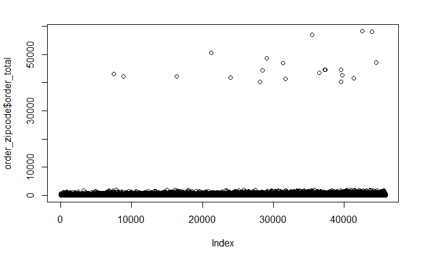

```r
# create a scatter plot
plot(order_zipcode$order_total)
```

The x-axis (horizontal) doesn’t have much meaning – it’s just the row number of the data in the spreadsheet. That’s why you see the plot end at about 45,000 on the x-axis.

However, the y-axis (vertical) represents the order total. It looks like most order totals are less than about $2,000. However, there is a set of orders that are very large - $40,000 to $60,000. And there is a large gap in-between that group and the rest. That’s suspicious so let’s isolate those orders.

Let’s examine the orders with greater than 25,000.

```r
# find the orders with the amount greater than 25000
order_zipcode%>%
  filter(order_total>25000)%>%
  group_by(state)%>%
  summarise(num_order=n())
```

|  | state | num_order |
| --- | --- | --- |
| 1 | AL | 1 |
| 2 | IL | 1 |
| 3 | LA | 1 |
| 4 | MA | 1 |
| 5 | MD | 1 |
| 6 | MI | 1 |
| 7 | MN | 1 |
| 8 | NC | 1 |
| 9 | NV | 2 |
| 10 | NY | 1 |

[output cut: 6 more lines]

That will be sure to get all of the outliers.

(You could have also chosen “35000,” or “32000,” or “10000.” Any number within that gap in the two sets of data points would work.)

You’ll see 21 rows left out of the original 45,808. Let’s remove those rows to see how much it affects the average order amount.

This time, we will save the result as a new dataset, `order_zipcode_cleaned`.

```r
# replace the order amount with NA
order_zipcode_cleaned <- order_zipcode %>%
  mutate(order_total = replace(order_total, order_total>25000, NA))
```

This command will delete the data in those filtered rows (i.e. replacing the values with NA), leaving the rest of the data unaffected.

Note that we did not get rid of the entire row, just the order_total column. We may want to use the rest of the data, which is correct, for other analyses.

Let’s calculate the average again for the cleaned dataset. Because the column contains NA values, the simple code `mean(order$order_total)` will return NA. You should tell R to calculate the average excluding NA’s using `na.rm=TRUE`.

```r
# recalculate the average
mean(order_zipcode_cleaned$order_total,na.rm=T)
```

```
[1] 136.8824
```

## Group_by & Summarise - Where do the orders come from?

Let’s dig the data little more. Now let’s figure out where these orders come from.

We will create a frequency table of orders by state and by zip code and sort them out based on the number of orders (not the total amount).

First, create a frequency table of the orders by state.

```r
# create a frequency table of the orders by state
table(order_zipcode_cleaned$state)
```

```
  AK   AL   AR   AZ   CA   CO   CT   DC   DE   FL   GA   HI   IA   ID   IL   IN   KS   KY
 244  994  777  579 2965  737  408  402   77 1634 1103  154 1005  218 1686 1216  822 1109
  LA   MA   MD   ME   MI   MN   MO   MS   MT   NC   ND   NE   NH   NJ   NM   NV   NY   OH
1002  699  876  683 1509 1194 1277  536  413 1281  465  717  277  587  465  317 2088 1934
  OK   OR   PA   PR   RI   SC   SD   TN   TX   UT   VA   VT   WA   WI   WV   WY
 859  419 2446  234  108  605  391  861 2664  429 1346  279  868  863  712  240
```

It returns the number of orders that come from each state. It is a simple way to get a frequency table. However, if you want to analyze data further by state, there is a more efficient way using `group_by()` and `summarise()`.

```r
order_zipcode_cleaned%>%
  group_by(state)%>%
  summarise(num_order=n())
```

|  | state | num_order |
| --- | --- | --- |
| 1 | AK | 244 |
| 2 | AL | 994 |
| 3 | AR | 777 |
| 4 | AZ | 579 |
| 5 | CA | 2965 |
| 6 | CO | 737 |
| 7 | CT | 408 |
| 8 | DC | 402 |
| 9 | DE | 77 |
| 10 | FL | 1634 |

[output cut: 43 more lines]

```r
NA
```

Some functions that will be handy to use for summarise include

- mean
- sum
- median
- min
- max

Let’s generate these summary statistics by states.

```r
order_zipcode_cleaned%>%
  group_by(state)%>%
  summarise(num_order=n(),
            mean=mean(order_total,na.rm=T),
            sum=sum(order_total,na.rm=T),
            median=median(order_total,na.rm=T),
            max=max(order_total,na.rm=T))
```

|  | state | num_order | mean | sum | median | max |
| --- | --- | --- | --- | --- | --- | --- |
| 1 | AK | 244 | 142.47893 | 34764.86 | 79.595 | 1206.79 |
| 2 | AL | 994 | 130.40686 | 129494.01 | 65.450 | 1576.47 |
| 3 | AR | 777 | 153.57602 | 119328.57 | 80.540 | 1597.67 |
| 4 | AZ | 579 | 125.99333 | 72950.14 | 68.530 | 1284.85 |
| 5 | CA | 2965 | 137.79130 | 408551.19 | 73.600 | 1810.86 |
| 6 | CO | 737 | 148.11900 | 109163.70 | 83.520 | 1831.51 |
| 7 | CT | 408 | 145.75615 | 59468.51 | 67.640 | 1041.68 |
| 8 | DC | 402 | 124.80684 | 50172.35 | 74.650 | 1542.07 |
| 9 | DE | 77 | 159.84234 | 12307.86 | 89.090 | 1177.44 |
| 10 | FL | 1634 | 127.74338 | 208732.69 | 62.005 | 1421.45 |

[output cut: 43 more lines]

```r
NA
```

```r
order_zipcode_cleaned%>%
  group_by(state,year)%>%
  summarise(num_order=n(),
            mean=mean(order_total),
            sum=sum(order_total),
            median=median(order_total),
            min=min(order_total),
            max=max(order_total))
```

| state | year | num_order | mean | sum | median | min | max |
| --- | --- | --- | --- | --- | --- | --- | --- |
| AK | 01 | 4 | 65.52250 | 262.09 | 41.780 | 25.03 | 153.50 |
| AK | 02 | 7 | 137.02429 | 959.17 | 170.270 | 36.33 | 206.06 |
| AK | 03 | 7 | 247.39143 | 1731.74 | 184.110 | 23.55 | 708.34 |
| AK | 04 | 13 | 126.73077 | 1647.50 | 63.320 | 21.06 | 533.49 |
| AK | 05 | 7 | 51.72286 | 362.06 | 39.070 | 15.34 | 112.28 |
| AK | 06 | 9 | 108.29556 | 974.66 | 76.650 | 20.12 | 262.62 |
| AK | 07 | 7 | 102.04429 | 714.31 | 79.490 | 22.64 | 274.44 |
| AK | 08 | 8 | 76.90125 | 615.21 | 56.605 | 17.71 | 161.03 |
| AK | 09 | 7 | 169.44429 | 1186.11 | 137.930 | 16.73 | 426.75 |
| AK | 10 | 7 | 127.53857 | 892.77 | 122.940 | 65.65 | 207.31 |

[output cut: 990 more lines]

## Group_by & Arrange - sorts a table based on a variable

Let’s sort the data based on the frequency of orders in a descending order in each state.

```r
# sort the data by the number of orders
order_zipcode_cleaned%>%
  group_by(state)%>%
  summarise(num_order=n())%>%
  arrange(desc(num_order))
```

| state | num_order |
| --- | --- |
| CA | 2965 |
| TX | 2664 |
| PA | 2446 |
| NY | 2088 |
| OH | 1934 |
| IL | 1686 |
| FL | 1634 |
| MI | 1509 |
| VA | 1346 |
| NC | 1281 |

[output cut: 43 more lines]

# Assignment 1

For each question, fill the R code area (in the grey color) to find the answer to the following questions. The same questions are posted on the Course Blackboard site under Blackboard>Assignment>Assignment 1.

Submit your answer for Question 1-4 through Blackboard>Assignment 1. You also need to compile this R markdown file and submit your report as well, as an answer for Question 5. I’ve demonstrated how to complete your Assignment during our online lecture. Please check the recorded lecture if you are in any doubt. If you have any remaining questions (after attending/watching the online lecture!), feel free to attend office hours (mine or TAs’) or email us.

Let’s examine the orders from MD. Make sure that you use the cleaned dataset, `order_zipcode_cleaned` that we created in the previous step above.

1. How many orders (i.e. the number of orders, not the total amount) came from MD (Maryland)? (hint: use `filter()`)

```r
order_zipcode_cleaned %>%
  filter(state == "MD") %>%
  nrow()
```

```
[1] 876
```

2. Are there any missing values in `order_total` among the orders from MD? You will filter the orders from MD AND filter the orders that have `NA` in `order_total`. How many orders from MD has missing value for order total? (hint: use `filter()`)

```r
order_zipcode_cleaned%>%
  filter(state == "MD") %>%
  filter(is.na(order_total)) %>%
  nrow()
```

```
[1] 1
```

3. Calculate the average (i.e. mean) `order_total` of the orders from MD. Make sure to include `na.rm=()` option. Without this option, you may get NA as an answer if there is at least one `NA` in order total. (hint: use `summarise()` with `na.rm=()`). Which one of the following is the closest number?

```r
order_zipcode_cleaned %>%
  filter(state == "MD") %>%
  summarise(mean = mean(order_total, na.rm = T))
```

| mean |
| --- |
| 110.9236 |

4. Count the number of orders by zipcode areas in MD. Which zip code area received more than 100 orders?

```r
order_zipcode_cleaned%>%
  filter(state == "MD") %>%
  group_by(zip_code) %>%
  summarise(num_order=n()) %>%
  filter(num_order > 100)
```

| zip_code | num_order |
| --- | --- |
| 20868 | 106 |
| 21037 | 110 |

5. Your last task is creating a report. Change the author’s name on the top of this R markdown file to your name. Then, compile this R markdown to a Word document(.doc) or an HTML file (.html). Submit this report as an answer for Question 5 of Assignment 1. Your report should contain all R codes and results. You don’t need to remove in-class exercise parts. It should be fine as long as your report includes the assignment questions and answers.